# Enrichment analysis

Load in libraries and functions to use in later analysis.

```r
easypackages::libraries("here","knitr")
code_dir = here("code")
datapath = here("data")
resultpath = here("results")
source(file.path(code_dir,"genelistOverlap.R"))

genelistOverlap <- function(list1,list2,backgroundTotal, print_result = TRUE, header = FALSE) {
# genelistOverlap
#
# Calculate enrichment odds ratio and p-value from hypergeometric test to
# answer the question of whether genes from one list are enriched in genes
# from another list.
#
# INPUT
#   list1 or list2 = excel file, tab or comma delimited file with gene IDs
#                    assuming each list has a header.
#   backgroundTotal = specify number of genes in background pool
#

    # Read in libraries and set options
    options(stringsAsFactors = FALSE)
    require(readxl)
    require(tools)

  if (is.character(list1)){
    # get the file extension of list1
    ext1 = file_ext(list1)

    if (is.element(ext1,c("xlsx","xls","txt","csv"))){
      if (ext1=="xlsx" | ext1=="xls") {
        genes1 = read_excel(list1)
      } else if (ext1=="txt") {
        genes1 = read.delim(list1, header = header)
      } else if (ext1=="csv") {
        genes1 = read.csv(list1, header = header)
      }# if (ext1=="xlsx" | ext1=="xls") {
    } else {
      genes1 = data.frame(list1)
    }# if (is.element(ext1,c("xlsx","xls","txt","csv"))){
  } else if (is.data.frame(list1)){
    genes1 = list1
  }# if (is.character(list1)){

  if (is.character(list2)){
    # get the file extension of list1
    ext2 = file_ext(list2)

    if (is.element(ext2,c("xlsx","xls","txt","csv"))){
      if (ext2=="xlsx" | ext2=="xls") {
        genes2 = read_excel(list2)
      } else if (ext2=="txt") {
        genes2 = read.delim(list2, header = header)
      } else if (ext1=="csv") {
        genes2 = read.csv(list2, header = header)
      }# if (ext1=="xlsx" | ext1=="xls") {
    } else {
      genes2 = data.frame(list2)
    }# if (is.element(ext1,c("xlsx","xls","txt","csv"))){
  } else if (is.data.frame(list2)){
    genes2 = list2
  }# if (is.character(list2)){

    # Find overlapping genes
    gene_mask = is.element(genes1[,1],genes2[,1])
    overlapping_genes = genes1[gene_mask,1]
    gene_overlap = sum(gene_mask)
    ngenes1 = length(genes1[,1])
    ngenes2 = length(genes2[,1])

    # Calculate odds ratio
    A = gene_overlap;
    B = ngenes1-gene_overlap
    if (ngenes2==gene_overlap){
      # add 0.5 to ngenes2 to avoid OR = Inf
      C = (ngenes2+0.5)-gene_overlap
    } else {
      C = ngenes2-gene_overlap
    }
    D = backgroundTotal-C
    OR = (A*D)/(B*C)

    # Calculate p-value from hypergeometric test
    hypergeo_p = sum(dhyper(gene_overlap:ngenes2,ngenes1,backgroundTotal-ngenes1,ngenes2))

    # pack into result
    result = vector(mode = "list", length = 1)
    result[[1]]$list1 = list1
    result[[1]]$list2 = list2
    result[[1]]$backgroundTotal = backgroundTotal
    result[[1]]$OR = OR
    result[[1]]$hypergeo_p = hypergeo_p
    result[[1]]$percent_overlap_list1 = gene_overlap/ngenes1
    result[[1]]$percent_overlap_list2 = gene_overlap/ngenes2
    result[[1]]$gene_overlap = gene_overlap
    result[[1]]$ngenes1 = ngenes1
    result[[1]]$ngenes2 = ngenes2
    result[[1]]$overlapping_genes = overlapping_genes

    # print result to the screen and then return result
    if (print_result){
      print(sprintf("OR = %f, p = %f",OR,hypergeo_p))
    }
    return(result)
} # function genelistOverlap
```

Examine how M10-NPC overlaps with co-expression modules from Lombardo et al., (2017). Hierarchical cortical transcriptome disorganization in autism. Molecular Autism, 8(1), 29.

```r
backgroundTotal = 8075
pm_mods = c("M1","M2","M3","M4","M5","M6","M7","M8","M9","M10",
            "M11","M12","M13","M14","M15","M16","M17","M18","M19","M20",
            "M21","M22","M23","M24","M25","M26","M27")

cols2use = c("OR","pval")
result = data.frame(matrix(nrow = length(pm_mods), ncol = length(cols2use)))
rownames(result) = pm_mods
colnames(result) = cols2use

M10_NPC = as.character(read.delim(file.path(datapath,"M10_NPC.txt"), header=FALSE)$V1)

for (mod in pm_mods){
  pm_genes = as.character(read.delim(file.path(datapath,sprintf("%s.txt",mod)),header=FALSE)$V1)
  res = genelistOverlap(list1 = M10_NPC, list2 = pm_genes, backgroundTotal =8075, print_result = FALSE)
  result[mod,"OR"] = res[[1]]$OR
  result[mod,"pval"] = res[[1]]$hypergeo_p
}
result$fdrq = p.adjust(result$pval, method = "fdr")
kable(result)
```

|  | OR | pval | fdrq |
| --- | --- | --- | --- |
| M1 | 0.8293114 | 0.9206686 | 1.0000000 |
| M2 | 0.4320479 | 0.9999798 | 1.0000000 |
| M3 | 0.4008294 | 0.9999907 | 1.0000000 |
| M4 | 0.2187143 | 0.9998830 | 1.0000000 |
| M5 | 0.1881984 | 0.9997339 | 1.0000000 |
| M6 | 2.5103544 | 0.0008702 | 0.0117476 |
| M7 | 0.1202319 | 0.9997709 | 1.0000000 |
| M8 | 1.4466001 | 0.1829230 | 1.0000000 |
| M9 | 0.1471810 | 0.9989640 | 1.0000000 |
| M10 | 0.0000000 | 1.0000000 | 1.0000000 |
| M11 | 2.2974238 | 0.0096317 | 0.0866852 |
| M12 | 0.1760523 | 0.9968578 | 1.0000000 |
| M13 | 0.1780979 | 0.9966463 | 1.0000000 |
| M14 | 0.1834215 | 0.9960537 | 1.0000000 |
| M15 | 0.6656224 | 0.8415083 | 1.0000000 |
| M16 | 0.2653061 | 0.9786947 | 1.0000000 |
| M17 | 0.0000000 | 1.0000000 | 1.0000000 |
| M18 | 0.2927322 | 0.9696071 | 1.0000000 |
| M19 | 0.0000000 | 1.0000000 | 1.0000000 |
| M20 | 0.3012094 | 0.9665179 | 1.0000000 |
| M21 | 0.0000000 | 1.0000000 | 1.0000000 |
| M22 | 0.7231981 | 0.7788179 | 1.0000000 |
| M23 | 1.6054217 | 0.2691614 | 1.0000000 |
| M24 | 0.4068478 | 0.9201174 | 1.0000000 |
| M25 | 15.5298128 | 0.0000000 | 0.0000000 |
| M26 | 0.0000000 | 1.0000000 | 1.0000000 |
| M27 | 1.7310219 | 0.3467052 | 1.0000000 |

```r
result["M25",]
```

```
##           OR         pval         fdrq
## M25 15.52981 1.240735e-14 3.349985e-13
```

```r
# show the overlapping genes between M25 and M10_NPC
M25 = as.character(read.delim(file.path(datapath,"M25.txt"),header=FALSE)$V1)
res = genelistOverlap(list1 = M10_NPC, list2 = M25, backgroundTotal =8075, print_result = FALSE)
write(res[[1]]$overlapping_genes, file = file.path(resultpath,"M10_NPC_M25_overlap.txt"))
res[[1]]$overlapping_genes
```

```
##  [1] "RPL31"  "RPL18A" "RPL19"  "RPS13"  "RWDD1"  "RPS12"  "EEF1B2" "RPS15"
##  [9] "RPL21"  "RPL23"  "RPS15A" "RPS2"   "SNRPG"  "RPS3"   "RPL27A" "RPL12"
## [17] "RPL23A" "RPL10A" "RPL39"
```

Examine how the Griesi-Oliveira et al., M10-NPC co-expression module overlaps with the autism-upregulated geneM15 co-expression module from Gandal et al., (2018). Transcriptome-wide isoform-level dysregulation in ASD, schizophrenia, and bipolar disorder. Science, 362(6420), eaat8127.

```r
# overlap between M10_NPC and the autism-upregulated geneM15 co-expression module from Gandal et al., 2018, Science
geneM15 = as.character(read.delim(file.path(datapath,"geneM15.txt"), header=FALSE)$V1)
res = genelistOverlap(list1 = M10_NPC, list2 = geneM15, backgroundTotal =8075, print_result = FALSE)
print(sprintf("OR = %s, p = %s",res[[1]]$OR,res[[1]]$hypergeo_p))
```

```
## [1] "OR = 19.1076555023923, p = 3.26547333407158e-34"
```

```r
write(res[[1]]$overlapping_genes, file = file.path(resultpath,"M10_NPC_geneM15_overlap.txt"))
res[[1]]$overlapping_genes
```

```
##  [1] "RPL26L1" "RPL31"   "RPL6"    "RPL3"    "RPL18A"  "RPL19"   "RPL34"
##  [8] "RPS13"   "RPS12"   "RPL24"   "EEF1B2"  "RPS15"   "RPL22"   "RPS25"
## [15] "RPL21"   "RPL5"    "RPL23"   "RPS15A"  "RPL35"   "RPLP1"   "RPL13A"
## [22] "RPS8"    "RPS27A"  "SNRPG"   "RPL32"   "RPS3A"   "RPL10"   "RPL7"
## [29] "RPL7A"   "RPS3"    "RPL29"   "RPL27A"  "RPL13"   "RPSA"    "RPS7"
## [36] "RPL4"    "RPS27"   "RPL14"   "RPL12"   "RPL23A"  "RPL10A"  "RPL39"
## [43] "RPL41"   "RPS18"
```

Overlap between Lombardo et al., M25 co-expression module and the autism-upregulated geneM15 co-expression module from Gandal et al., (2018).

```r
# overlap M25 from Lombardo et al., and geneM15 from Gandal et al., 2018, Science
M25 = as.character(read.delim(file.path(datapath,"M25.txt"),header=FALSE)$V1)
res = genelistOverlap(list1 = M25, list2 = geneM15, backgroundTotal =8075, print_result = FALSE)
print(sprintf("OR = %s, p = %s",res[[1]]$OR,res[[1]]$hypergeo_p))
```

```
## [1] "OR = 140.276595744681, p = 1.09263234479455e-54"
```

```r
write(res[[1]]$overlapping_genes, file = file.path(resultpath,"M25_geneM15_overlap.txt"))
res[[1]]$overlapping_genes
```

```
##  [1] "ATOX1"  "ATP5G2" "COMMD6" "EEF1B2" "FAU"    "MYL6"   "PFDN5"  "POLR2I"
##  [9] "RPL10A" "RPL12"  "RPL18A" "RPL19"  "RPL21"  "RPL23"  "RPL23A" "RPL26"
## [17] "RPL27A" "RPL30"  "RPL31"  "RPL35A" "RPL36"  "RPL37A" "RPL39"  "RPL8"
## [25] "RPS11"  "RPS12"  "RPS13"  "RPS14"  "RPS15"  "RPS15A" "RPS20"  "RPS3"
## [33] "RPS4X"  "RPS5"   "RPS9"   "SNRPG"  "UBA52"  "UXT"
```

Take the gene sets (M10_NPC, M25, geneM15) as well as the overlap between M10_NPC and M25 or geneM15, and input them into STRING (https://string-db.org/). This will give us a visualization of the gene sets and the overlapping gene sets. For this analysis we used all the default settings in STRING (see below). For the M10_NPC, M25, and geneM15 gene sets, we highlighted the ribosomal proteins in red, as indicated by the UniProt enrichment for “Ribosomal protein” (KW-0689).

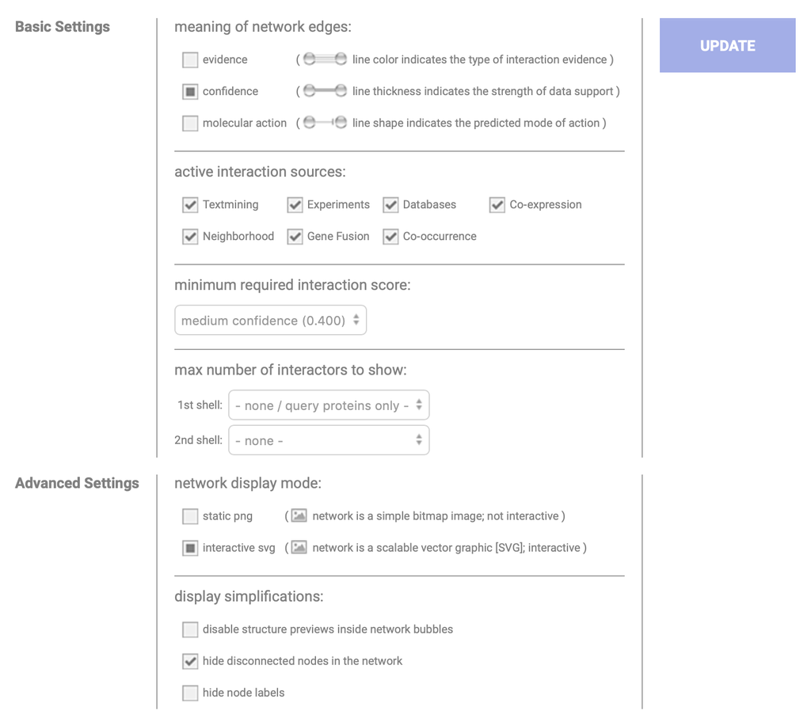

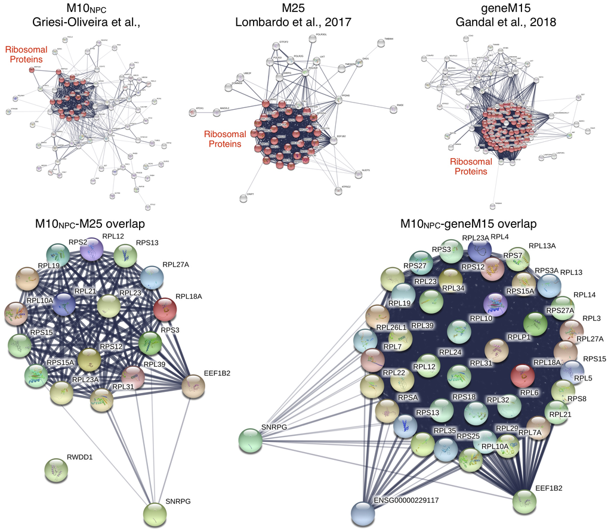